# FRNL CS 2.10

# Evaluation of fodder beet + catch crop rotation (FRNL)

Table 1. Summary of observed and simulated data

```
[1] "Working in K:/Rainshelter/Fodderbeet 2016-2017/Analysis"
```

## Get class of variable

- just to facet later and organise things

```
                       VarName            VarClass
 FodderBeet.Leaf.CoverTotal: 1   Soil_Nitrogen:19
 FodderBeet.Leaf.LAI       : 1   Biomass      : 9
 FodderBeet.Leaf.Live.Wt   : 1   Soil_Water   : 9
 FodderBeet.Leaf.NConc     : 1   Nitrogen     : 8
 FodderBeet.Petiole.Live.Wt: 1   Soil_Temp    : 8
 FodderBeet.Petiole.NConc  : 1   Canopy       : 4
 (Other)                   :55   (Other)      : 4
                       VarName        Nit           Irr         Clock.Today
 FodderBeet.Leaf.CoverTotal:  2580   0  :52460   Dry  :78690   Min.   :2016-09-28
 FodderBeet.Leaf.LAI       :  2580   300:52460   Irrig:78690   1st Qu.:2017-01-13
 FodderBeet.Leaf.Live.Wt   :  2580   50 :52460                 Median :2017-04-30
 FodderBeet.Leaf.NConc     :  2580                             Mean   :2017-04-30
 FodderBeet.Petiole.Live.Wt:  2580                             3rd Qu.:2017-08-16
 FodderBeet.Petiole.NConc  :  2580                             Max.   :2017-12-01
 (Other)                   :141900
 CropOper.Script.CropSown                     SimName         SimValue                  VarClass
 Fallow    :31842         RS_RotationNit0IrrFull  :26230   Min.   :   0.0000   Soil_Nitrogen:49020
 FodderBeet:81984         RS_RotationNit0IrrNil   :26230   1st Qu.:   0.0000   Biomass      :23220
 Oats      :43554         RS_RotationNit300IrrFull:26230   Median :   0.1907   Soil_Water   :23220
                          RS_RotationNit300IrrNil :26230   Mean   :  12.1912   Nitrogen     :20640
                          RS_RotationNit50IrrFull :26230   3rd Qu.:   4.5016   Soil_Temp    :20640
                          RS_RotationNit50IrrNil  :26230   Max.   :2186.4117   Canopy       :10320
                                                                               (Other)      :10320
```

## Change data format

- gather variable names pre-merging

```
[1] "Found 29 variables"
```

# Model evaluation

## 1. Simulated x Observed graphs

## 2. Basic statistics

Selection of stats indexes to use, at the moment we’re following the refs:

1. Moriasi, D.N., Arnold, J.G., Van Liew, M.W., Bingner, R.L., R.D., H., Veith, T.L., 2007. Model evaluation guidelines for systematic quantification of accuracy in watershed simulations. Transactions of the ASABE 50, 885-900
2. Gauch Jr, H.G., Hwang, J.T.G., Fick, G.W., 2003. Model evaluation by comparison of model-based predictions and measured values. Agron. J. 95, 1442-1446

Initial criteria of a very good model performance (Moriasi et al 2007 plus some guesses):

This adds beyond the regression based analysis above.

- R2 > 75% (?)
- RMSE of 0 (< 25% is very good?)
- NSE of 1.0 (>0.75 is very good)
- LC = 100% (>80% is very good?)
- Pbias of 0 (< +-0.15 is very good; + is underestimation and - is overestimation)
- RSR of 0 (0 to 0.5 is very good)

There’s quite a bit o duplication in these (e.g. pBias and SB are very similar) but we cover well most metrics.

- For the moment, consider accurate if rRMSE is < 25%
- Black line is x=y (1:1 line)
- Colour lines are linear fits for dryland and irrigated crops

| VarName | n | r2 | r_rmse | nse | lc | rsr | Accuracy |
| --- | --- | --- | --- | --- | --- | --- | --- |
| FodderBeet.Leaf.LAI | 36 | 78.9 | 41.8 | 0.6 | 59.1 | 0.6 | LOW |

| VarName | n | r2 | r_rmse | nse | lc | rsr | Accuracy |
| --- | --- | --- | --- | --- | --- | --- | --- |
| FodderBeet.Leaf.Live.Wt | 36 | 81.5 | 44.3 | 0.4 | 28.8 | 0.8 | LOW |
| FodderBeet.Petiole.Live.Wt | 36 | 65.0 | 67.0 | 0.5 | 71.8 | 0.7 | LOW |
| FodderBeet.StorageRoot.Live.Wt | 36 | 81.7 | 31.2 | 0.8 | 90.0 | 0.4 | LOW |

| VarName | n | r2 | r_rmse | nse | lc | rsr | Accuracy |
| --- | --- | --- | --- | --- | --- | --- | --- |
| FodderBeet.Leaf.NConc | 36 | 46.6 | 16.5 | 0.4 | 87.2 | 0.8 | GOOD |
| FodderBeet.Petiole.NConc | 36 | 70.1 | 39.7 | -0.2 | 25.5 | 1.1 | LOW |
| FodderBeet.StorageRoot.NConc | 36 | 81.5 | 23.1 | 0.8 | 77.6 | 0.5 | GOOD |

| VarName | n | r2 | r_rmse | nse | lc | rsr | Accuracy |
| --- | --- | --- | --- | --- | --- | --- | --- |
| Soil.SoilWater.SW.1 | 1212 | 86.2 | 20.8 | 0.8 | 71.5 | 0.4 | GOOD |
| Soil.SoilWater.SW.2 | 1212 | 74.4 | 22.1 | 0.6 | 61.7 | 0.6 | GOOD |
| Soil.SoilWater.SW.3 | 1212 | 64.5 | 21.3 | 0.6 | 82.2 | 0.7 | GOOD |
| Soil.SoilWater.SW.4 | 1212 | 53.0 | 27.9 | 0.0 | 46.6 | 1.0 | LOW |
| Soil.SoilWater.SW.5 | 1212 | 59.6 | 21.6 | -0.7 | 24.1 | 1.3 | GOOD |
| Soil.SoilWater.SW.6 | 1212 | 16.6 | 20.6 | -2.4 | 24.9 | 1.8 | GOOD |
| Soil.SoilWater.SW.7 | 1212 | 2.7 | 25.6 | -0.9 | 50.1 | 1.4 | LOW |
| Soil.SoilWater.SW.8 | 1212 | 0.0 | 70.8 | -1.2 | NA | 1.5 | LOW |

| VarName | n | r2 | r_rmse | nse | lc | rsr | Accuracy |
| --- | --- | --- | --- | --- | --- | --- | --- |
| Soil.Temperature.1 | 1212 | 66.0 | 21.1 | 0.4 | 59.1 | 0.8 | GOOD |
| Soil.Temperature.2 | 1212 | 73.1 | 15.3 | 0.6 | 60.6 | 0.7 | GOOD |
| Soil.Temperature.3 | 1212 | 72.0 | 12.7 | 0.6 | 74.0 | 0.6 | GOOD |
| Soil.Temperature.4 | 1212 | 69.1 | 10.4 | 0.6 | 71.0 | 0.7 | GOOD |
| Soil.Temperature.5 | 1212 | 63.1 | 9.4 | 0.5 | 68.6 | 0.7 | GOOD |
| Soil.Temperature.6 | 1212 | 58.4 | 8.6 | 0.2 | 55.1 | 0.9 | GOOD |
| Soil.Temperature.7 | 1212 | 53.6 | 8.2 | 0.0 | 47.2 | 1.0 | GOOD |

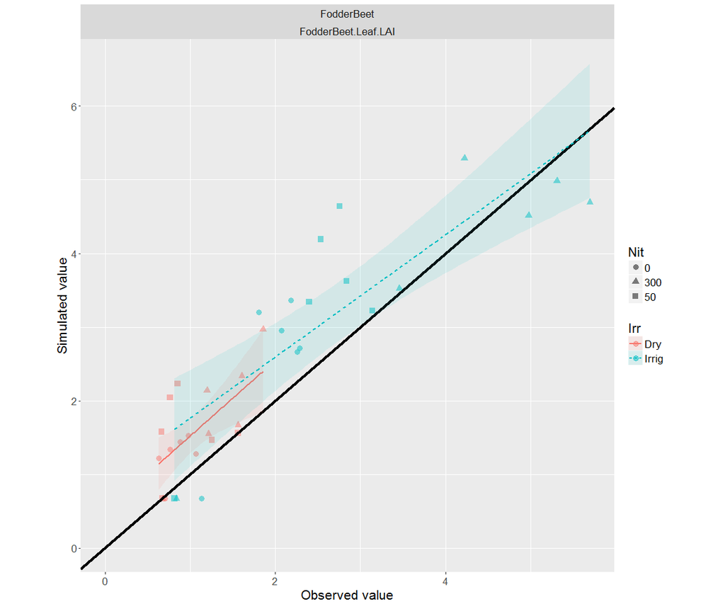

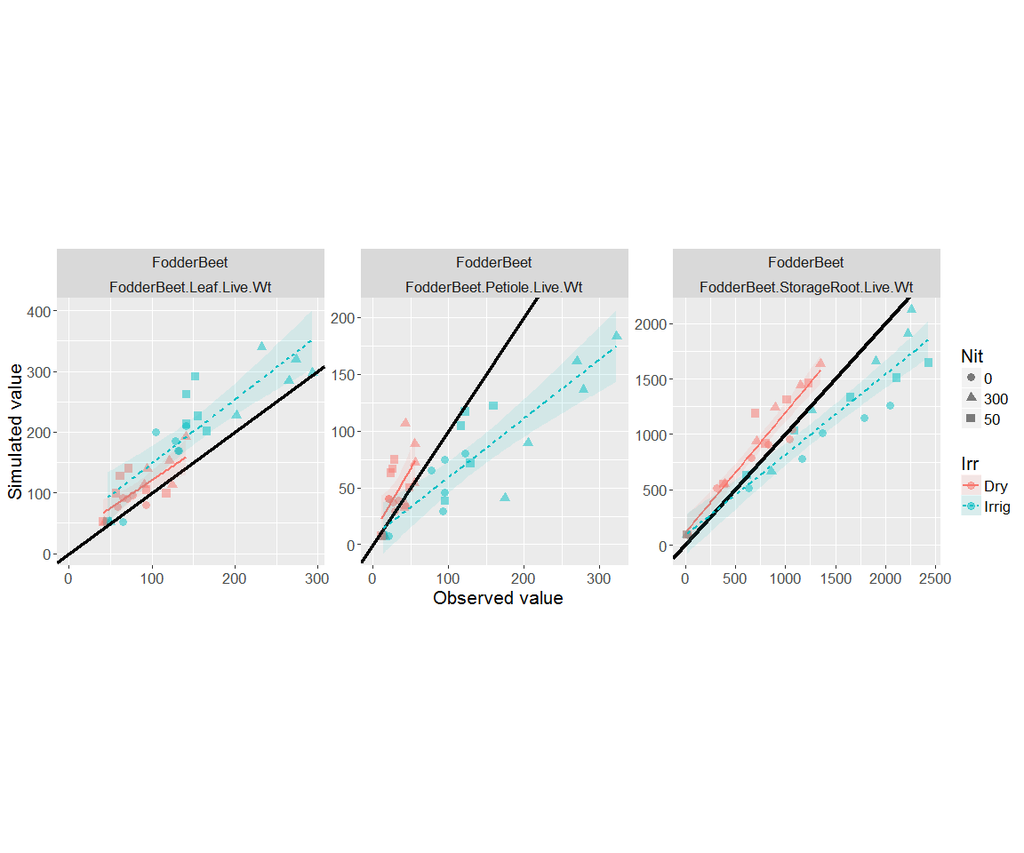

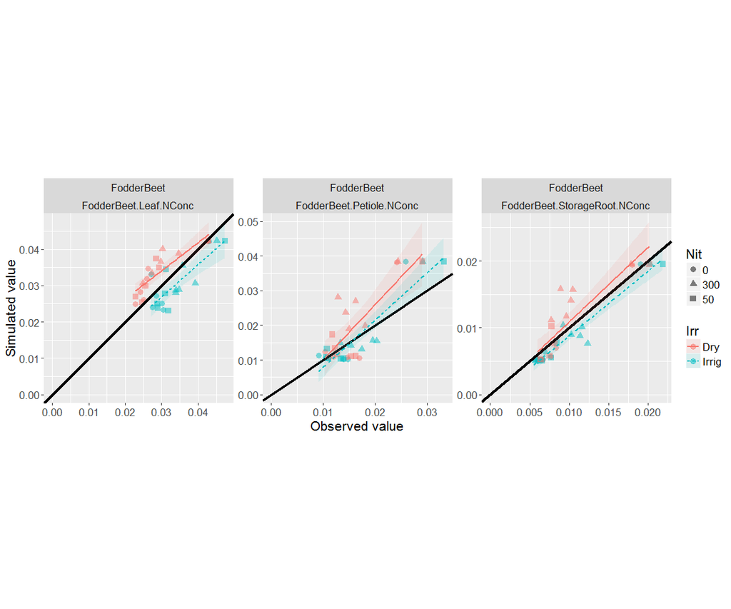

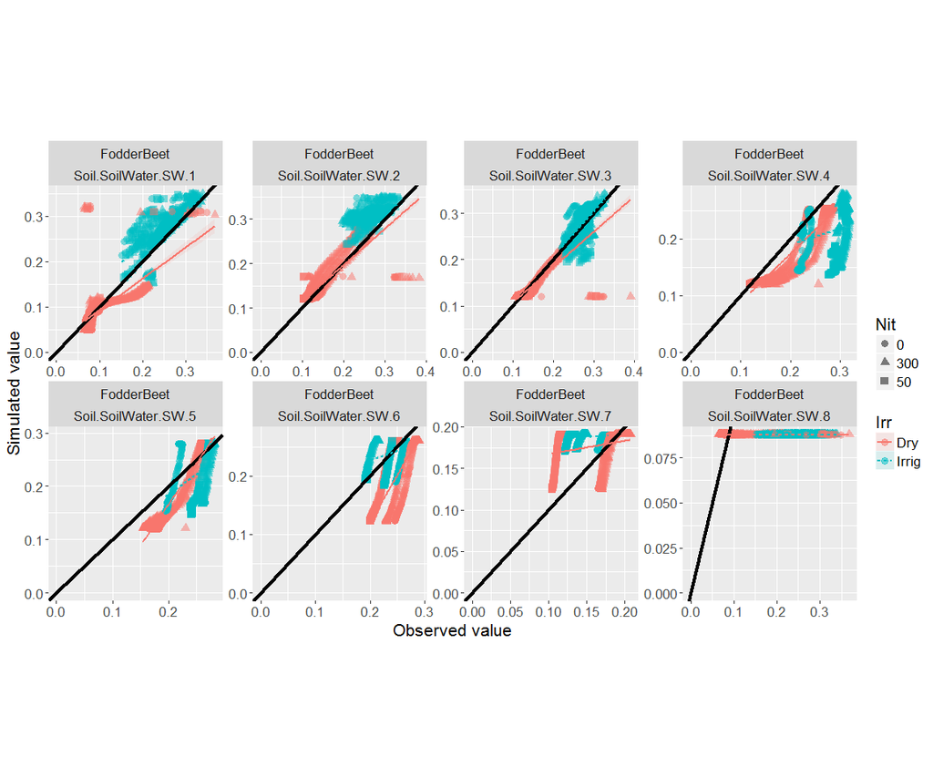

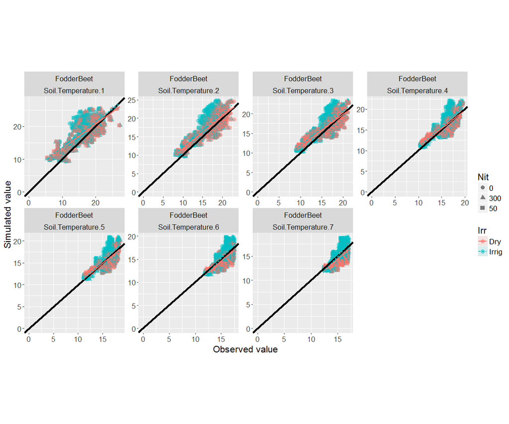

# Time series of soil

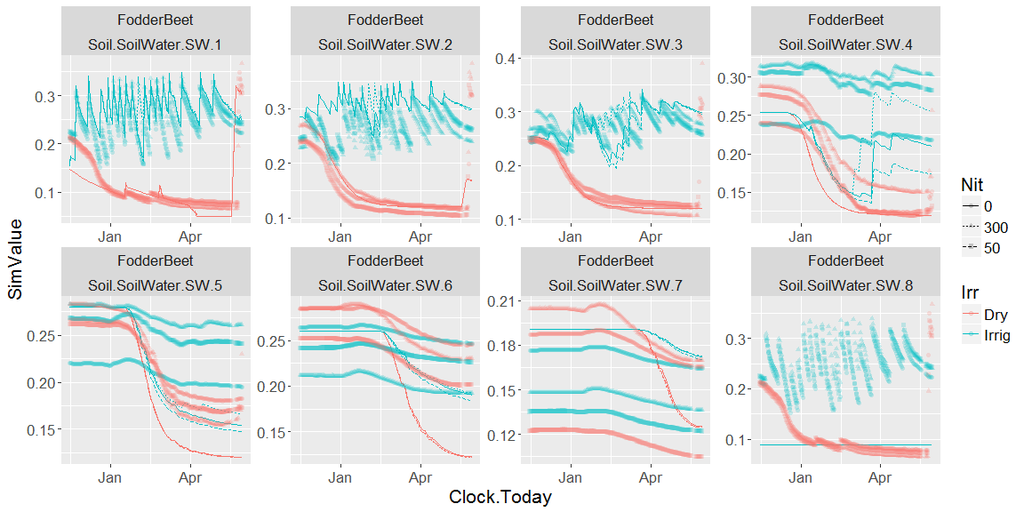

```r
mergedDF %>%
  filter(VarClass == "Soil_Water") %>%
  na.omit()%>%
  filter(CropOper.Script.CropSown!="Fallow") %>%
  ggplot(aes(colour=Irr,shape=Nit, linetype=Nit)) +
  geom_line(aes(x=Clock.Today,y=SimValue)) +
  geom_point(aes(x=Clock.Today,y=ObsValue), alpha=0.2) +
  facet_wrap(CropOper.Script.CropSown~VarName, scales='free', ncol=4)+
    theme(text = element_text(size=16))
```

## 3. Sensibility analysis

- Criteria: Are simulated values sensible in relation to real life experiences?

Get weather data

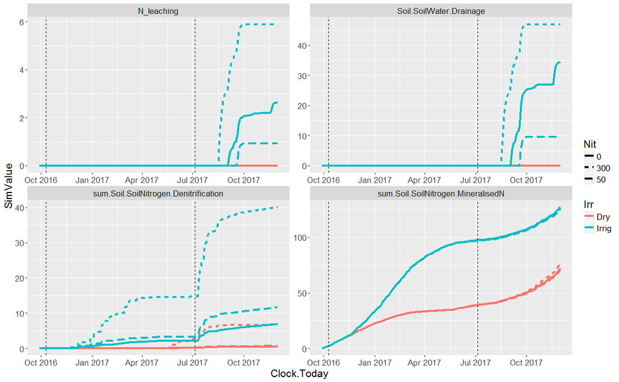

## 4. Sensitivity analysis

- Placeholder for possible sensitivity analysis in APSIM-X
- Which parameters to test?